# Econometrie II : Transports

Rapport

Guewen HESLAN - Bijan VALILOU

Janvier 2021

# Introduction

L’objectif ce projet est d’expliquer la quantité de diesel consommée par les camions à partir des autres variables proposées et d’effectuer des prévisions à horizon 2025. Nous allons donc tenter de répondre à la question suivante : quels déterminants agissent dans la formation de la quantité de pétrole consommée par les camions ? Pour y répondre nous allons proposé un modèle économétrique et le confronter à divers tests afin d’évaluer sa validité.

# Présentation des données

Nous disposons d’un jeu de données comprenant huit séries réunissant des données de 1985 à 2019.

Consommation de gazole des camions

| Année | Quantité transportée par routes | Quantité transportée par train | Prix du disel (euros/litre de diesel) | Quantité de diesel consommé (en milliers de tonnes) | PIB en monnaie constante (base 100=2014) | Indice des prix à la consommation (base 100=2015) | Quantité de diesel consommé des camions (en milliers de tonnes) | PIB en volume (en milliards d’euros 2014) |
| --- | --- | --- | --- | --- | --- | --- | --- | --- |
| 1985 | 128.42 | 56.06 | 0.60 | 11467 | 7.576890e+11 | 61.28 | 7999.56 | 1253.77 |
| 1986 | 134.60 | 52.69 | 0.52 | 12364 | 8.145960e+11 | 62.83 | 8378.00 | 1283.07 |
| 1987 | 144.52 | 52.71 | 0.50 | 13309 | 8.559830e+11 | 64.90 | 8874.91 | 1315.94 |
| 1988 | 161.11 | 52.95 | 0.49 | 14903 | 9.252150e+11 | 66.65 | 10083.36 | 1378.36 |
| 1989 | 168.64 | 53.71 | 0.52 | 16472 | 9.971210e+11 | 68.98 | 11026.46 | 1438.23 |
| 1990 | 197.02 | 52.24 | 0.54 | 17908 | 1.053546e+12 | 71.19 | 12847.49 | 1480.29 |
| 1991 | 202.67 | 52.43 | 0.55 | 18729 | 1.091705e+12 | 73.48 | 13088.60 | 1495.80 |
| 1992 | 208.34 | 51.18 | 0.53 | 19824 | 1.130983e+12 | 75.21 | 13520.35 | 1519.72 |
| 1993 | 204.24 | 45.58 | 0.56 | 20711 | 1.142119e+12 | 76.80 | 13736.33 | 1510.17 |
| 1994 | 219.27 | 48.87 | 0.59 | 21735 | 1.179867e+12 | 78.07 | 13944.66 | 1545.79 |
| 1995 | 234.50 | 48.27 | 0.59 | 22869 | 1.218273e+12 | 79.47 | 14175.76 | 1578.35 |
| 1996 | 238.55 | 50.11 | 0.65 | 23489 | 1.252266e+12 | 81.04 | 14106.16 | 1600.65 |
| 1997 | 246.95 | 54.25 | 0.68 | 24566 | 1.292777e+12 | 82.02 | 14718.88 | 1638.05 |
| 1998 | 257.65 | 54.10 | 0.64 | 25667 | 1.351896e+12 | 82.55 | 15658.43 | 1696.83 |
| 1999 | 266.86 | 54.54 | 0.69 | 26667 | 1.400999e+12 | 83.00 | 16588.18 | 1754.89 |
| 2000 | 276.86 | 57.73 | 0.85 | 27355 | 1.478585e+12 | 84.39 | 16920.64 | 1823.74 |
| 2001 | 290.43 | 51.72 | 0.80 | 28684 | 1.538200e+12 | 85.77 | 16846.18 | 1859.92 |
| 2002 | 293.38 | 51.29 | 0.77 | 29670 | 1.587829e+12 | 87.42 | 17155.59 | 1881.04 |
| 2003 | 296.99 | 48.06 | 0.79 | 30081 | 1.630666e+12 | 89.25 | 17034.63 | 1896.53 |
| 2004 | 314.90 | 46.35 | 0.88 | 30762 | 1.704019e+12 | 91.16 | 17539.55 | 1950.19 |
| 2005 | 314.15 | 40.70 | 1.03 | 31048 | 1.765905e+12 | 92.76 | 17707.32 | 1982.63 |
| 2006 | 327.61 | 41.18 | 1.07 | 31891 | 1.848151e+12 | 94.31 | 18073.35 | 2031.19 |
| 2007 | 339.95 | 42.61 | 1.09 | 32958 | 1.941360e+12 | 95.71 | 17911.82 | 2080.44 |
| 2008 | 327.44 | 40.44 | 1.27 | 32827 | 1.992380e+12 | 98.41 | 17474.79 | 2085.74 |
| 2009 | 284.40 | 32.13 | 1.00 | 32881 | 1.936422e+12 | 98.49 | 16954.37 | 2025.81 |
| 2010 | 300.40 | 29.96 | 1.15 | 33588 | 1.995289e+12 | 100.00 | 17245.84 | 2065.31 |
| 2011 | 300.16 | 34.18 | 1.34 | 34049 | 2.058369e+12 | 102.11 | 17561.67 | 2110.59 |
| 2012 | 283.45 | 32.55 | 1.40 | 34120 | 2.088804e+12 | 104.11 | 17591.77 | 2117.20 |
| 2013 | 292.00 | 32.00 | 1.35 | 34272 | 2.117189e+12 | 105.01 | 17653.77 | 2129.40 |
| 2014 | 288.50 | 32.20 | 1.28 | 34407 | 2.149765e+12 | 105.54 | 17703.04 | 2149.76 |
| 2015 | 281.50 | 34.30 | 1.15 | 34803 | 2.198432e+12 | 105.58 | 17757.19 | 2173.69 |
| 2016 | 287.70 | 32.60 | 1.11 | 34777 | 2.234129e+12 | 105.77 | 17809.40 | 2197.50 |
| 2017 | 307.70 | 33.42 | 1.23 | 34690 | 2.297242e+12 | 106.86 | 18328.21 | 2247.86 |
| 2018 | 317.30 | 31.98 | 1.44 | 33626 | 2.363306e+12 | 108.84 | 17270.02 | 2289.78 |
| 2019 | 322.30 | 31.58 | 1.44 | 32770 | 2.437635e+12 | 110.05 | 16344.30 | 2331.98 |

[figure not shown]

# Estimation et tests du premier modèle

## Les variables explicatives choisies

Six variables sont proposées dans le but d’expliquer la quantité de diesel consommée par les camions (sans compter l’ensemble des transformations possibles). Afin d’obtenir un modèle pertinent nous avons réalisé différents choix justifiés.

Nous avons immédiatement exclu la quantité de diesel consommée au total qui comprend la variable que l’on tente d’expliquer : la consommation globale de diesel semble davantage être une conséquence qu’une cause de l’évolution de la quantité de diesel consommé par les camions.

On pourrait supposer que la quantité acheminée par rail soit le témoin d’une substitution entre les différents modes d’acheminement des marchandises. Même si le transport par route connaît une croissance forte tandis que celui par rail décroît comme les figures 1 et 2 le montrent, on peut observer la forte différence d’échelle entre les utilisation des deux modes de transport. On remarque également que les variations qui suivent après les années 2000 n’entraîne pas de réponse significative sur l’une comme sur l’autre. L’évolution du transport ferroviaire ne semble pas être un déterminant du transport routier, mais une conséquence de l’évolution de facteurs structurels et politiques comme Pierre Zembri l’a mis en lumière (Zembri 2004).

## Équation modèle et régression

$$\begin{equation}
\label{eq:modele1}
Q_{DCamion} = \beta_0 + \beta_1*\frac{P_{diesel}}{IPC} + \beta_2*PIB + \beta_3*Q_{route} + \varepsilon
\end{equation}$$

Le premier modèle (1) suit l’équation avec les variables :

- $Q_{DCamion}$ : La quantité de diesel consommée par les camions ;
- $PIB$ : Le PIB français en volume ;
- $P_{diesel}$ : Le prix du diesel ;
- $IPC$ : L’indice des prix à la consommation ;
- $Q_{route}$ : La quantité de marchandises transportées par route ;
- $\beta_n$ : Le coefficient associé à la n-ième variable explicative.

Toutes les variables obtenues sont significatives, car la probabilité qu’elles soient nulles est inférieure à 5%. La variable $x1$ désigne l’effet du prix du diesel, déflaté du niveau général des prix, qui a un effet négatif très fort sur la consommation de diesel des camions. Le gazole est donc un bien ordinaire, avec une élasticité-prix négative de la demande. La variable $x2$ représente l’effet du PIB mesuré en volume. Le coefficient associé est positif, ce qui signifie que l’augmentation du produit intérieur a un effet sectoriel positif sur le secteur du transport par camion et donc de la consommation de gazole. La variable $x3$ vise la quantité de transport par route, qui a un effet positif sur la consommation de diesel. Le coefficient de détermination $R^2$ est de $94\%$, ce qui signifie une forte adéquation entre le modèle et les données observées.

|  | Estimate | Std. Error | t value | Pr(>\|t\|) |
| --- | --- | --- | --- | --- |
| **(Intercept)** | 1767 | 790.8 | 2.235 | 0.03277 |
| **x1** | -378013 | 120267 | -3.143 | 0.003667 |
| **x2** | 4.242 | 1.423 | 2.98 | 0.005559 |
| **x3** | 36.89 | 5.615 | 6.57 | 2.449e-07 |

Fitting linear model: y ~ x

| Observations | Residual Std. Error | $R^2$ | Adjusted $R^2$ |
| --- | --- | --- | --- |
| 35 | 721.2 | 0.9475 | 0.9424 |

Nous allons effectuer un ensemble de tests sur le premier modèle estimer afin de voir quelles manipulations sont nécessaires pour accroître la validité du modèle.

## Tests de stabilité temporelle

Afin de détecter l’instabilité des coefficients dans un modèle de régresson sans connaître la date a posteriori, nous allons effectuer un test de Cusum proposé par Brown, Durbins et Evans (1975). Ce test repose sur la somme cumulée réduites des résidus récursifs $W_r$, ie normalisée avec l’écart-type résiduel $S_r$ :

$$\begin{equation}
\label{eq:wr}
W_r = \frac{1}{S} \overset{r}{\underset{i=K+1}{\sum}} w_j
\end{equation}$$

avec

$$\begin{equation}
\label{eq:S}
S = \sqrt{\frac{\overset{n}{\underset{i=1}{\sum}} \hat{\varepsilon}_i^2}{n - K}}
\end{equation}$$

En observant la figure 8, nous remarquons que $W_r$ ne s’écarte pas significativement de la droite $W_r = 0$ et reste entre les deux droites représentant le risque de première espèce $\alpha$. Le problème de ce test de ne pas prendre en compte le risque de deuxième espèce.

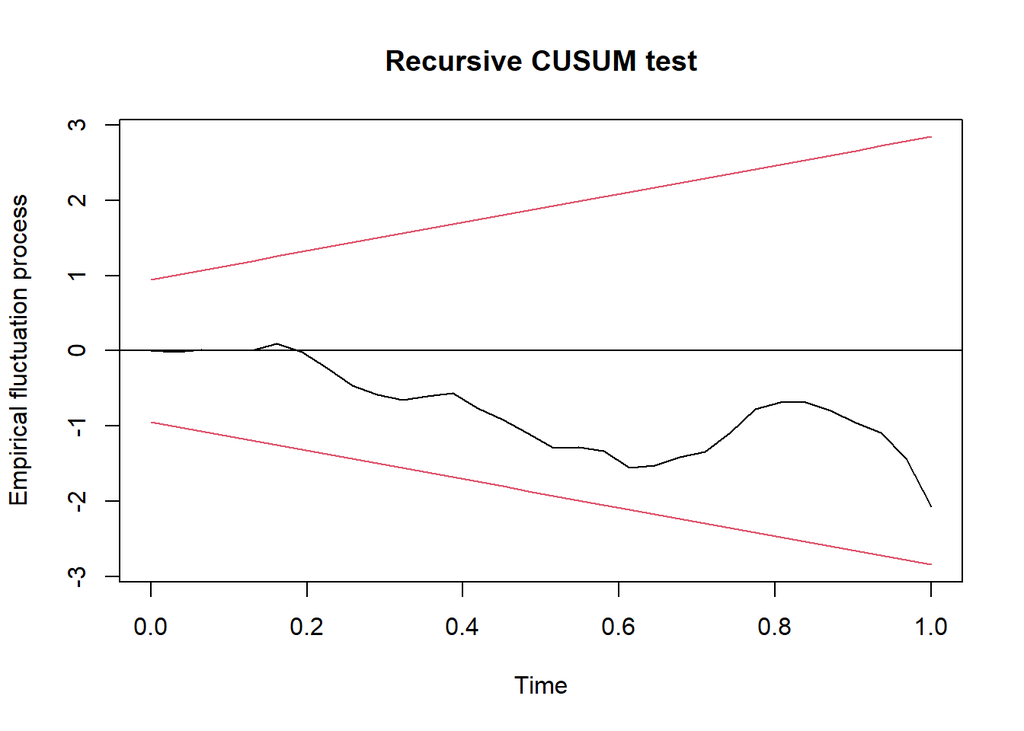

Fig. 8 : Test de Cusum de stabilité temporelle du modèle 1

Le second test de Brown, Durbin et Evans (1975) est fondé sur le Cusumsquare, ie les sommes des carrés résidus :

$$\begin{equation}
\label{eq:sr}
s_r = \frac{\overset{r}{\underset{i=K+1}{\sum}} w_j^2}{\overset{n}{\underset{i=K+1}{\sum}} w_j^2}
\end{equation}$$

Nous comparons la significativité de l’écart de $s_r$ à son espérance sous l’hypothèse nulle de constance des coefficients $H_0$, grâce à un couple de droites parallèles. Nous remarquons qu’à partir de 1998, la statistique $s_r$ est au-delà des valeurs limites.

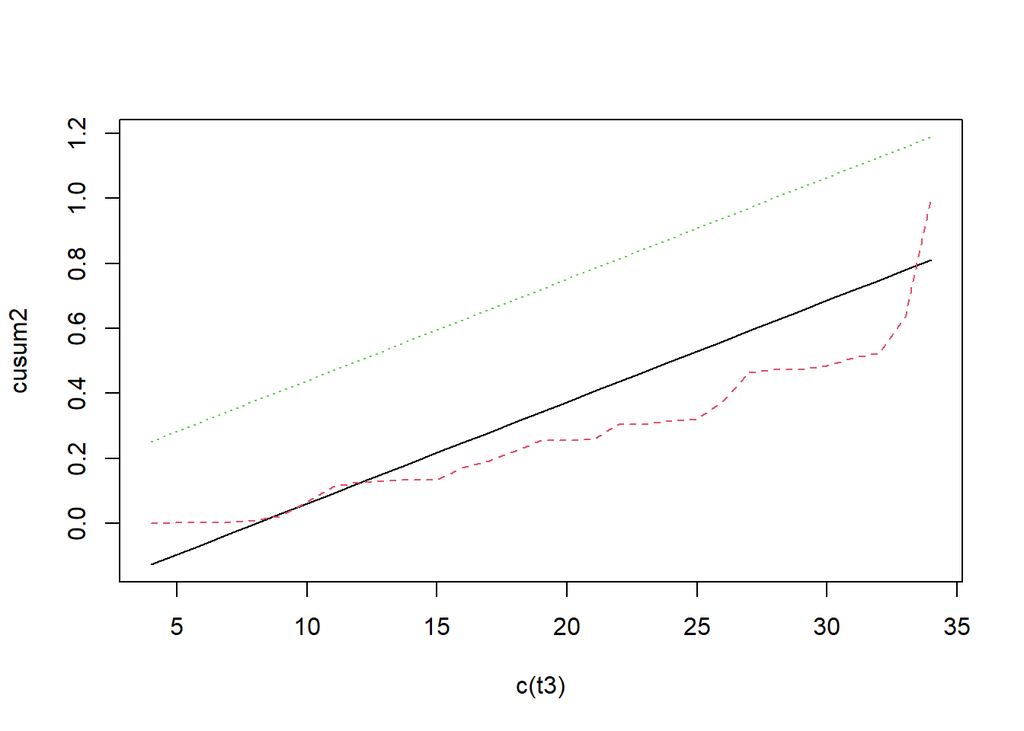

Fig. 9 : Test de Cusumsquare de stabilité temporelle du modèle 1

Une fois que la période de rupture est approximativement estimée, nous pouvons mettre en oeuvre le test de Chow (1960), qui permet de savoir si les paramètres du modèle ont été modifiés à partir d’un rang d’observation. Le test de Chow effectue une régression sur un échantillon de $n$ obervations (hypothèse nulle $H_0$) contre une alternative de l’estimation du modèle sur deux sous-périodes $n_1$ et $n_2$ avec $n_1 + n_2 = n$. L’hypothèse nulle s’exprime sous la forme :

$$\begin{equation}
\label{eq:H0chow}
H_0 : y = X\beta + \varepsilon
\end{equation}$$

Le test de Chow calcul une statistique de Fischer fondée sur la somme des carrés des résidisu sur l’échantillon complet $SCR_0$ et la somme des carrés des résidus du moèle alternatif $SCR_1$ sur chaque sous-période:

$$\begin{equation}
\label{eq:statF}
F(K,n-2K) = \frac{\frac{SCR_0 - SCR_1}{K}}{\frac{SCR_1}{n - 2K}}
\end{equation}$$

La p-value est-en dessous de 5%, donc nous pouvons rejeter $H_0$ de la régression du modèle. Pour dater précisément l’année de rupture, il faut évaluer la statistique de Fischer. Celle-ci est la plus élevée pour l’année 2001, avec F= 11,39. La rupture a donc lieu en 2001.

Test de Chow de 1995 à 2004

|  | statistic | p.value | method | data.name |
| --- | --- | --- | --- | --- |
| 1995 | c(F = 4.64283563594701) | c(F = 0.00554738443120117) | Chow test | y ~ x |
| 1996 | c(F = 4.65133772559658) | c(F = 0.00549683616410357) | Chow test | y ~ x |
| 1997 | c(F = 5.79601334234664) | c(F = 0.0016800265235527) | Chow test | y ~ x |
| 1998 | c(F = 8.51147927330835) | c(F = 0.000140588189987745) | Chow test | y ~ x |
| 1999 | c(F = 10.7641179888783) | c(F = 2.38893676115515e-05) | Chow test | y ~ x |
| 2000 | c(F = 11.17276760355) | c(F = 1.77208419261943e-05) | Chow test | y ~ x |
| 2001 | c(F = 11.3979272051564) | c(F = 1.50725877964275e-05) | Chow test | y ~ x |
| 2002 | c(F = 10.5854028432303) | c(F = 2.72788003993218e-05) | Chow test | y ~ x |
| 2003 | c(F = 10.0026924784759) | c(F = 4.24242733156888e-05) | Chow test | y ~ x |
| 2004 | c(F = 9.93197977353754) | c(F = 4.48030603892313e-05) | Chow test | y ~ x |

# Estimation et tests de stabilité temporelle du modèle 2

## Estimation du modèle 2 en séparant les variables explicatives par sous-période

En observant la figure 3 (cf. supra), le prix du diesel est la série marquée par la plus grande variance. Nous essayons donc de séparer la variable explicative prix du diesel sur deux sous-périodes : une allant de 1985 à 2000 et l’autre de 2001 à 2019. Nous créons une nouvelle variable $\frac{P_{diesel}^{2001-2019}}{IPC^{2001-2019}}$ (toutes les valeurs de la variable de 1985 à 2000 sont nulles) dissociée de la variable $\frac{P_{diesel}^{1985-2000}}{IPC^{1985-2000}}$ (toutes les valeurs de la variable de 2001 à 2019 sont nulles).

$$\begin{equation}
\label{eq:modele2}
Q_{DCamion} = \beta_0 + \beta_1*\frac{P_{diesel}^{1985-2000}}{IPC^{1985-2019}} + \beta_2*\frac{P_{diesel}^{2001-2019}}{IPC^{2001-2019}} + \beta_3*PIB + \beta_4*Q_{route} + \varepsilon
\end{equation}$$

|  | Estimate | Std. Error | t value | Pr(>\|t\|) |
| --- | --- | --- | --- | --- |
| **(Intercept)** | 117.4 | 1670 | 0.07026 | 0.9445 |
| **x1** | -294623 | 141025 | -2.089 | 0.04528 |
| **x2** | -365083 | 120331 | -3.034 | 0.004947 |
| **x3** | 4.871 | 1.525 | 3.195 | 0.003283 |
| **x4** | 37.35 | 5.607 | 6.661 | 2.231e-07 |

Fitting linear model: y ~ x

| Observations | Residual Std. Error | $R^2$ | Adjusted $R^2$ |
| --- | --- | --- | --- |
| 35 | 718.3 | 0.9496 | 0.9429 |

## Tests de stabilité temporelle

Si on effectue un test de Cusumsquare , nous observons toujours une instabilité temporelle comme le démontre la figure 10.

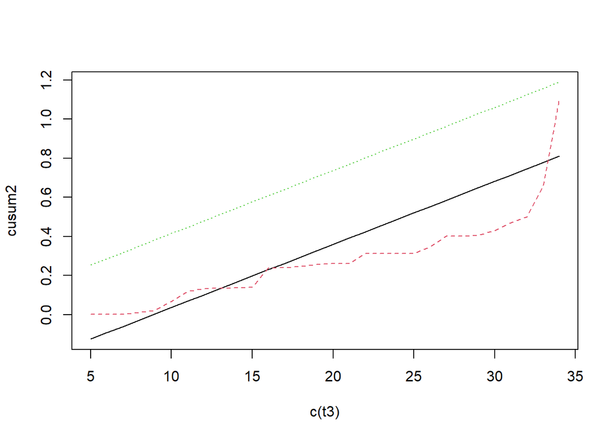

Fig. 10 : Test de Cusumsquare de stabilité temporelle du modèle 2

[figure not shown]

```r
ggplot()+
  geom_line(aes(x=Transport_France2019$Year, y=res, color="Résidus"))+
  geom_line(aes(x=Transport_France2019$Year, y=y, color="Valeur estimée de y \n par le modèle"))+
  geom_line(aes(x=Transport_France2019$Year, y=yf, color="Valeur réelle de y"))+
  labs(x = "Année", y = "Consommation de gazole par camion (en milliers de tonnes)", title = "Fig.8 Comparaison des résidus et \n des valeurs estimées par le modèle 1") +
    theme(axis.text=element_text(size=7),axis.title=element_text(size=11),title = element_text(size=9), plot.title = element_text(hjust = 0.5, vjust = 0.5)) +
  scale_x_continuous(breaks=seq(1985,2020,5))
```

Fig. 11 : Courbe des résidus

# Estimation et tests de validité du modèle 3

## Estimation du modèle 3

Il s’agit du même modèle présenté précédemment, mais sans la valeur de l’année 2019.

|  | Estimate | Std. Error | t value | Pr(>\|t\|) |
| --- | --- | --- | --- | --- |
| **(Intercept)** | -1710 | 1328 | -1.288 | 0.208 |
| **x1** | -243723 | 107888 | -2.259 | 0.03157 |
| **x2** | -355441 | 91627 | -3.879 | 0.0005548 |
| **x3** | 6.237 | 1.196 | 5.217 | 1.389e-05 |
| **x4** | 34.15 | 4.321 | 7.902 | 1.026e-08 |

Fitting linear model: y ~ x

| Observations | Residual Std. Error | $R^2$ | Adjusted $R^2$ |
| --- | --- | --- | --- |
| 34 | 546.8 | 0.9717 | 0.9678 |

## Tests de validité

### Test de stabilité temporelle

Le test de Cusumsquare décrit supra confirme l’absence de rupture dans le modèle 3.

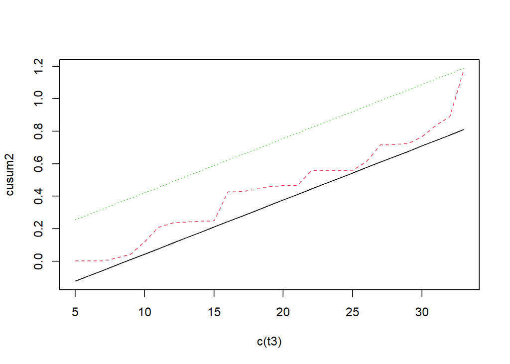

Fig. 12 : Test de Cusumsquare de stabilité temporelle du modèle 3

### Test d’autocorrélation des résidus

Le test de Breusch-Godrey permet de tester la significativité du coefficient $\rho$ qui représente l’autocorrélation des résidus :

$$\begin{equation}
\label{eq:BG}
\varepsilon = \rho \varepsilon_{t-1} + u_t
\end{equation}$$

L’hypothèse nulle $H_0$ revient à dire que $\rho=0$, ie l’autocorrélation est nulle. L’hypothèse laternative $H_1$ suppose que $\rho \ne 0$, ie l’autocorrélation des résidus est existante. En l’espèce, la p-value est signficaitive au seuil de 5%, donc nous rejettons l’hypothèse $H_0$ d’absence d’autocorrélation.

Breusch-Godfrey test for serial correlation of order up to 2: `y ~ x`

| Test statistic | df | P value |
| --- | --- | --- |
| 15.76 | 2 | 0.0003776 * * * |

### Test de normalité des résidus

La statistique de Jarque et Bera s’écrit :

$$\begin{equation}
\label{eq:JB}
JB = \frac{T-(p+q)}{6} \left ( S^2 + \frac{1}{4}(K-3)^2 \right )
\end{equation}$$

L’hypothèse $H_0$ de normalité des résidus revient à dire que : $JB \sim \chi^2$. La p-value n’est pas significative au seuil de 5%. Nous ne rejetons donc pas l’hypothèse nulle de normalité des résidus.

Jarque Bera Test: `res`

| Test statistic | df | P value |
| --- | --- | --- |
| 1.461 | 2 | 0.4816 |

### Test d’homoscédasticité

Nous utilisons le test de Breusch-Pagan pour analyser l’hétéroscédasticité. En l’espèce, la p-value n’est pas significative au seuil de 5%. NOus ne rejetons pas l’hypothèse nulle d’homoscédasticité.

studentized Breusch-Pagan test: `y ~ x`

| Test statistic | df | P value |
| --- | --- | --- |
| 7.619 | 4 | 0.1066 |

# Prévisions à l’horizon 2025 à partir du modèle 3

Nous nous reposons sur le jeu d’hypothèse suivant sur les variables explicatives. Celle-ci est basée sur un ensemble de scénarios concernant les prix du diesel et du PIB.

valeur des variables explicatives de 2019 à 2025

| Année | Prix du diesel déflaté du niveau général des prix | PIB en volume | Quantité de biens transportés par route |
| --- | --- | --- | --- |
| 2019 | 0.0130851 | 2331.980 | 322.3000 |
| 2020 | 0.0122955 | 2366.593 | 318.4368 |
| 2021 | 0.0109369 | 2503.562 | 310.7104 |
| 2022 | 0.0103514 | 2602.636 | 317.5538 |
| 2023 | 0.0112309 | 2653.216 | 339.6291 |
| 2024 | 0.0129140 | 2690.018 | 350.2253 |
| 2025 | 0.0127575 | 2723.548 | 355.7441 |

La prédiction à partir des estimations du modèle 3 revient à calculer :

$$\hat{y}_f = x_f' \tilde{\beta}$$

A partir de la figure 13, nous remarquons que la consommation de gazole par camion augmente. La consommation de gazole par camion en 2025 est de 22 888 milliers de tonnes.

Tableau des prévisions de 2019 à 2025

| Année | Valeur de la prévison | Borne inférieure | Borne supérieure | Ecart-type de prévision |
| --- | --- | --- | --- | --- |
| 2019 | 19188.15 | 17991.34 | 20384.95 | 586.0169 |
| 2020 | 19552.77 | 18313.19 | 20792.35 | 606.9632 |
| 2021 | 20626.08 | 19105.00 | 22147.16 | 744.7982 |
| 2022 | 21685.75 | 19974.69 | 23396.81 | 837.8221 |
| 2023 | 22442.39 | 20817.47 | 24067.32 | 795.6448 |
| 2024 | 22435.51 | 20906.54 | 23964.48 | 748.6606 |
| 2025 | 22888.71 | 21318.02 | 24459.41 | 769.0916 |

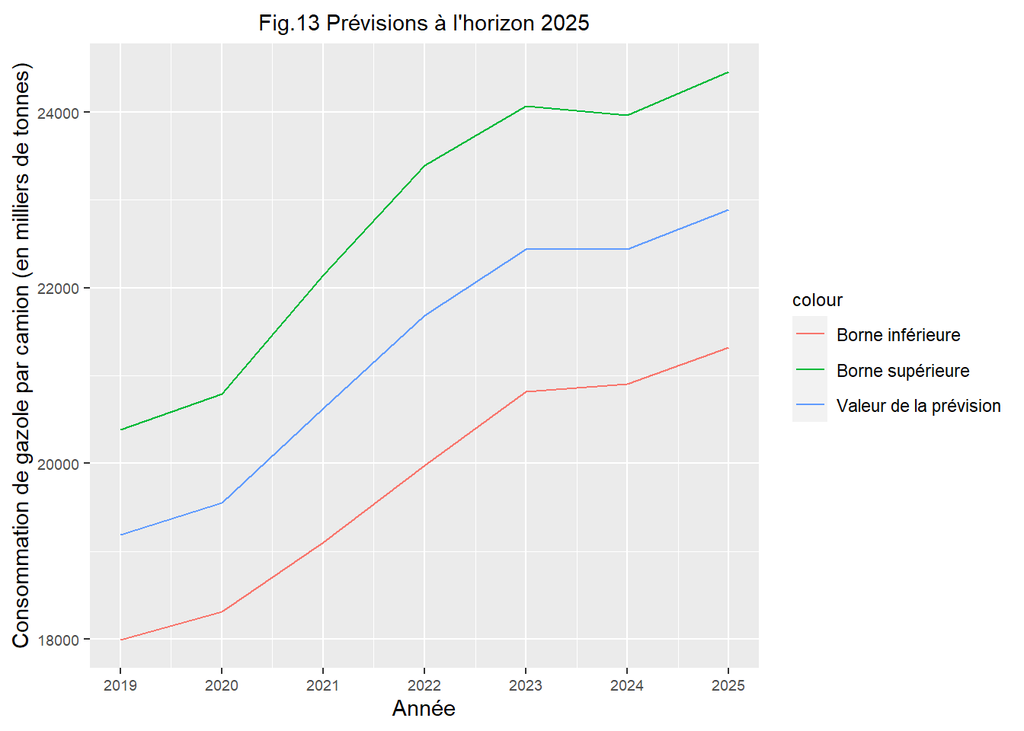

```r
rmse=sqrt(t(Transport_France2019_prev$Qdieselcamion[35]-z[2,2])%*% (Transport_France2019_prev$Qdieselcamion[35]-z[2,2])/2)
cat("Valeur de l'erreur quadratique moyenne RMSE (sur les années 2018 et 2019) :",rmse)
```

```
## Valeur de l'erreur quadratique moyenne RMSE (sur les années 2018 et 2019) : 2268.731
```

# Bibliographie

Zembri, Pierre. 2004. “Pourquoi le fret ferroviaire va-t-il si mal en France ?” *Flux* 5657 (2): 106–11. https://www.cairn.info/revue-flux1-2004-2-page-106.htm.